# A persistent lack of international representation on editorial boards in environmental biology | PLOS Biology

Skip to main content

Advertisement

  [Save](https://journals.plos.org/plosbiology/article/metrics?id=10.1371/journal.pbio.2002760#savedHeader)

  [Citation](https://journals.plos.org/plosbiology/article/metrics?id=10.1371/journal.pbio.2002760#citedHeader)

  [View](https://journals.plos.org/plosbiology/article/metrics?id=10.1371/journal.pbio.2002760#viewedHeader)

  [Share](https://journals.plos.org/plosbiology/article/metrics?id=10.1371/journal.pbio.2002760#discussedHeader)

Open Access

Perspective

[Perspective](https://journals.plos.org/plosbiology/s/other-article-types#perspective) The Perspective section provides experts with a forum to comment on topical or controversial issues of broad interest.

[See all article types »](https://journals.plos.org/plosbiology/s/other-article-types)

# A persistent lack of international representation on editorial boards in environmental biology

- Johanna Espin,
- Sebastian Palmas,
- Farah Carrasco-Rueda,
- Kristina Riemer,
- Pablo E. Allen,
- Nathan Berkebile,
- Kirsten A. Hecht,
- Kay Kastner-Wilcox,
- Mauricio M. Núñez-Regueiro,
- Candice Prince,
- Constanza Rios,
- Erica Ross,
- Bhagatveer Sangha,
- [ ... ],
- Emilio M. Bruna
- [ view all ]

# A persistent lack of international representation on editorial boards in environmental biology

- Johanna Espin,
- Sebastian Palmas,
- Farah Carrasco-Rueda,
- Kristina Riemer,
- Pablo E. Allen,
- Nathan Berkebile,
- Kirsten A. Hecht, …

x

## Abstract

The scholars comprising journal editorial boards play a critical role in defining the trajectory of knowledge in their field. Nevertheless, studies of editorial board composition remain rare, especially those focusing on journals publishing research in the increasingly globalized fields of science, technology, engineering, and math (STEM). Using metrics for quantifying the diversity of ecological communities, we quantified international representation on the 1985–2014 editorial boards of 24 environmental biology journals. Over the course of 3 decades, there were 3,827 unique scientists based in 70 countries who served as editors. The size of the editorial community increased over time—the number of editors serving in 2014 was 4-fold greater than in 1985—as did the number of countries in which editors were based. Nevertheless, editors based outside the “Global North” (the group of economically developed countries with high per capita gross domestic product [GDP] that collectively concentrate most global wealth) were extremely rare. Furthermore, 67.18% of all editors were based in either the United States or the United Kingdom. Consequently, geographic diversity—already low in 1985—remained unchanged through 2014. We argue that this limited geographic diversity can detrimentally affect the creativity of scholarship published in journals, the progress and direction of research, the composition of the STEM workforce, and the development of science in Latin America, Africa, the Middle East, and much of Asia (i.e., the “Global South”).

## Figures

[figure not shown]

**Citation:** Espin J, Palmas S, Carrasco-Rueda F, Riemer K, Allen PE, Berkebile N, et al. (2017) A persistent lack of international representation on editorial boards in environmental biology. PLoS Biol 15(12): e2002760. https://doi.org/10.1371/journal.pbio.2002760

**Published:** December 12, 2017

**Copyright:** © 2017 Espin et al. This is an open access article distributed under the terms of the [Creative Commons Attribution License](http://creativecommons.org/licenses/by/4.0/), which permits unrestricted use, distribution, and reproduction in any medium, provided the original author and source are credited.

**Data Availability:** All relevant data used in the paper and its Supporting Information files are archived in the Dryad Digital Repository (https://doi.org/10.5061/dryad.6jn86.2 and https://doi.org/10.5061/dryad.mh189). The code used for the analyses presented in this paper is archived online (http://doi.org/10.5281/zenodo.1067800) and is available for download and improvement at https://github.com/embruna/Espin_etal_Editors.

**Funding:** The authors received no specific funding for this work.

**Competing interests:** The authors have declared that no competing interests exist.

**Abbreviations:** EB, environmental biology; GDP, gross domestic product; STEM, science, technology, engineering, and math

**Provenance:** Not commissioned; externally peer reviewed.

## Introduction

There are currently over 28,000 peer-reviewed academic journals [1], and the scholars who serve on the editorial boards of these journals play a major role in defining the trajectory and boundaries of knowledge in their disciplines [2]. This is because board members are responsible for coordinating the evaluation by outside experts of a manuscript’s technical aspects and the “importance” or “novelty” of the research it summarizes, i.e., peer review, on which the decision to publish a manuscript is ultimately based. Editors also play a central but underappreciated role in shaping the community of scholars contributing to the discourse in their field. First, by recommending the publication of an article, the editor confers legitimacy not only on the research but also upon the individuals who carried it out [3,4]. Second, editors help choose new editors. In doing so, they confer enhanced status and visibility on a select group of scholars who then benefit from the unique opportunities for professional advancement provided by board membership [5]. Editors are therefore a small but powerful group of “gatekeepers” [2] that select the scientists and ideas shaping the direction of their discipline.

The increased recognition of editor power, along with the results of studies on workforce diversity [6], have heightened concerns about how the composition of editorial boards might influence the peer-review process [7]. For example, it has been suggested that boards whose members are demographically homogenous might converge on a narrow suite of research topics and approaches they consider worthy of publication [3,4]. This narrow vision—and the board structure driving it—could be perpetuated by editors nominating collaborators whose perspectives and backgrounds likely match their own for board service. Indeed, this is among the principal reasons put forward to explain why women remain severely underrepresented on editorial boards across academic fields [5], which has consequences for the selection of referees and other critical aspects of the editorial process [8].

Recent decades have seen the rapid globalization of research in science, technology, engineering, and math (STEM), resulting in greater representation in international journals of authors based in the “Global South” [9,10], i.e., the world’s “developing” or “emerging” economies located primarily in Latin America, Asia, Africa, and the Middle East. Having editorial boards that reflect this increasing geographic diversity of the global scientific community is thought to benefit both journals and disciplines in ways that parallel the benefits resulting from other forms of diversity. In field-based sciences such as ecology or geology, for example, editors based in the region where studies are conducted will be more familiar with the environmental, social, and economic context and constraints under which they were carried out [11]. This could ensure both more rigorous review and a fairer assessment of reviewer criticisms and proposed improvements. Furthermore, scientists trained in different parts of the world can also have very different epistemological orientations. Increasing geographic diversity on an editorial board could therefore broaden the scope of theoretical and methodological approaches a journal publishes. Ultimately, these benefits of internationalization could help to minimize apparent biases in the review, publication, and citation of articles based on an author’s nationality or home country [10,12].

The first systematic efforts to quantify the nationality of STEM editors—often by using the country in which they were based as a proxy for nationality—were carried out in the early 1980s [13,14]. Since then, a small but growing number of studies have observed similar patterns as these early ones did—individual editorial boards tend to be dominated by scholars from or based in the US and the UK [7]. However, prior studies typically compared board composition of journals using data from only a single calendar year, which makes it impossible to evaluate how the community of gatekeepers has changed over time. Furthermore, most of the journals reviewed are from the physical sciences, medical fields, or lab-based biological sciences [4,15]. As a result, almost nothing is known about the geographic diversity of editors in field-based STEM disciplines [16] such as ecology, evolution, and natural resource management (hereafter, environmental biology [EB]).

The term “diversity” is often used colloquially to refer to the representation of different groups in a focal population or workplace. However, one can formally quantify the diversity of a community (e.g., an assemblage of editors) using a suite of indices derived from information theory. While the indices differ in their assumptions and applications, the most commonly used are calculated using 2 types of information: the number of categories found in a sample (i.e., “richness”) and the relative abundance of these categories (i.e., “evenness”). Most studies of editorial board composition to date only report the number of countries represented by editors, i.e., geographic richness. However, diversity indices permit a more nuanced evaluation of community composition. For example, using only richness might lead one to conclude that the geographic representation of editors based in different countries has remained steady over time, when, in fact, 1 country has become numerically dominant. Another advantage of diversity indices is that they can be compared across groups (e.g., journals), even if the groups differ in richness or population size.

We identified all scientists serving from 1985–2014 on the editorial boards of 24 leading journals in EB (S1 Table) and the countries in which they were based during their board tenure. We then calculated the geographic richness and geographic diversity of this editor community and quantified how it has changed over the last 3 decades. Finally, we assessed the geographic distribution of editors at broader geographic and macroeconomic scales by comparing the representation of editors from different World Bank geographic regions and national income categories. Details on data collection and analysis are in S1 Text; data used in this study are archived at the Dryad repository: https://doi.org/10.5061/dryad.6jn86.2 and https://doi.org/10.5061/dryad.mh189 [17,18].

### How geographically diverse is the editorial community?

[figure not shown]

Download:

- PPT

  larger image
- TIFF

  original image

Fig 1. Community composition of editors in environmental biology (1985–2014).

https://doi.org/10.1371/journal.pbio.2002760.g001

[figure not shown]

Download:

- PPT

  PowerPoint slide
- PNG

  larger image
- TIFF

  original image

Fig 2. The percentage of environmental biology editors based in different countries, global regions, and World Bank national income categories.

(A) Countries. (B) World Bank global regions. (C) World Bank gross national income categories. The DOIs for the datasets used in this paper (both archived at Dryad) are https://doi.org/10.5061/dryad.6jn86.2 and https://doi.org/10.5061/dryad.mh189. AUS, Australia; CAN, Canada; CHE, Switzerland; DEU, Germany; FRA, France; GBR, United Kingdom; NLD, Netherlands; OECD, Organization for Economic Cooperation and Development; SWE, Sweden; USA, United States of America.

https://doi.org/10.1371/journal.pbio.2002760.g002

[figure not shown]

Download:

- PPT

  PowerPoint slide
- PNG

  larger image
- TIFF

  original image

Table 1. Percentage of the editorial board members from 24 environmental biology journals based in different (A) World Bank country income categories and (B) global regions.

https://doi.org/10.1371/journal.pbio.2002760.t001

### Why does geographic diversity matter?

Although the increasing geographic richness of editors is a positive development, it is dispiriting that geographic diversity remains unchanged. Unfortunately, it will remain low until a greater proportion of editors are based outside of the US and the UK. But does a lack of geographic representation—be it at the national, regional, or macroeconomic level—have consequences for the process of evaluating manuscripts that could ultimately limit the scope and direction of research in EB? Put bluntly, do editors and reviewers from high-income regions like the US or the UK have biases—implicit or otherwise—that affect how they evaluate submissions from scientists based in the Global South? Although 1 journal in our survey found no evidence that reviewer or author nationality influences the likelihood manuscripts are accepted [23,24], this contrasts sharply with the results of prior studies in other STEM fields [25]. There is also compelling evidence that the region in which authors are based affects where their papers are ultimately published and how much they are cited [10,26,27]. In light of these results and the ample data on how gender and ethnic background influence other aspects of academic evaluation [28], we recommend that editors in chief work to increase the geographic representation on their boards, make editorial board members and referees aware of how biases based on author nationality can affect their editorial judgement, and conduct internal analyses of the potential factors influencing manuscript fate.

Internationalizing editorial boards can also have positive impacts for journals in addition to mitigating possible implicit biases. First, scientists who presume their work will not be judged fairly because of their nationality or where they are based (i.e., the “biased author effect” [29]) may be more likely to submit their manuscripts to journals that have editors representing their region. This both increases the number and scope of submissions a journal receives and the size and expertise of its reviewer pool. Second, a globally diverse editorial board can serve as an important signal of journal quality and connote prestige [29], especially to those tasked with evaluating individual, institutional, or national scientific productivity [15]. Third, it can enhance the profile and impact of the journal and articles published (to say nothing of justification for editors to demand more support or resources from their publishers). Finally, capacity building is central to the mission of academic societies. By providing editorial opportunities to scholars from emerging scientific regions, society journals can play a pivotal role in achieving this goal.

### Geographic diversity: Identifying disparities and setting goals

Decades of research have highlighted the positive influence of diversity on scientific research teams [30]. Although we recognize editorial boards do not operate in precisely the same way as workplace teams, we believe that increases in their geographic diversity can similarly enhance the creativity and impact of scholarship published in scientific journals. We reiterate prior calls [16] for journal leadership to, at the very least, strive for editorial boards whose regional distribution of editors mirrors that of authors (Fig 3 and S2 Table, S2 Fig). However, we also encourage complementing these efforts by including editors based on criteria such as where a journal’s authors work [11,22] and where their expertise is needed [31,32]. Because the size of editorial boards is typically smaller than the number of countries meeting these criteria, we suggest editors attempt to recruit from less-represented countries within a focal region as opportunities arise.

[figure not shown]

Download:

- PPT

  PowerPoint slide
- PNG

  larger image
- TIFF

  original image

Fig 3. Cumulative geographic richness of editors and authors in environmental biology (1985–2014).

Rarefaction curves were generated using data on the editorial board membership of 24 environmental biology journals (S1 Table) and the institutional addresses of authors publishing in those journals (*N* = 113,256 publications; S1 Text). The DOIs for the datasets used in this paper (both archived at Dryad) are https://doi.org/10.5061/dryad.6jn86.2 and https://doi.org/10.5061/dryad.mh189.

https://doi.org/10.1371/journal.pbio.2002760.g003

Regardless of the criteria used to identify areas from which to increase representation, however, efforts must be led by specific plans and timetables to provide both guidance to editors and hold them accountable for their commitments [33]. Whether such plans underlie the geographic diversity we observed on a few of the editorial boards we reviewed is unknown (S3–S6 Figs). Nevertheless, these examples of journals with geographically widespread editors further undermine the frequent argument that it is challenging to find and recruit board members from the Global South with the requisite academic background, editorial experience, and time to serve. We believe that recruiting these editors is the ethical duty of a journal’s leadership, especially given the impact their presence on the board can have on the global scientific community and the diffusion of the knowledge they create in the service of society. Where to find them? We humbly suggest their large and geographically diverse pool of authors (Fig 3, S2 Fig) is an ideal place to start.

## Supporting information

A persistent lack of international representation on editorial boards in environmental biology

Showing 1/9: S1 Fig.tif

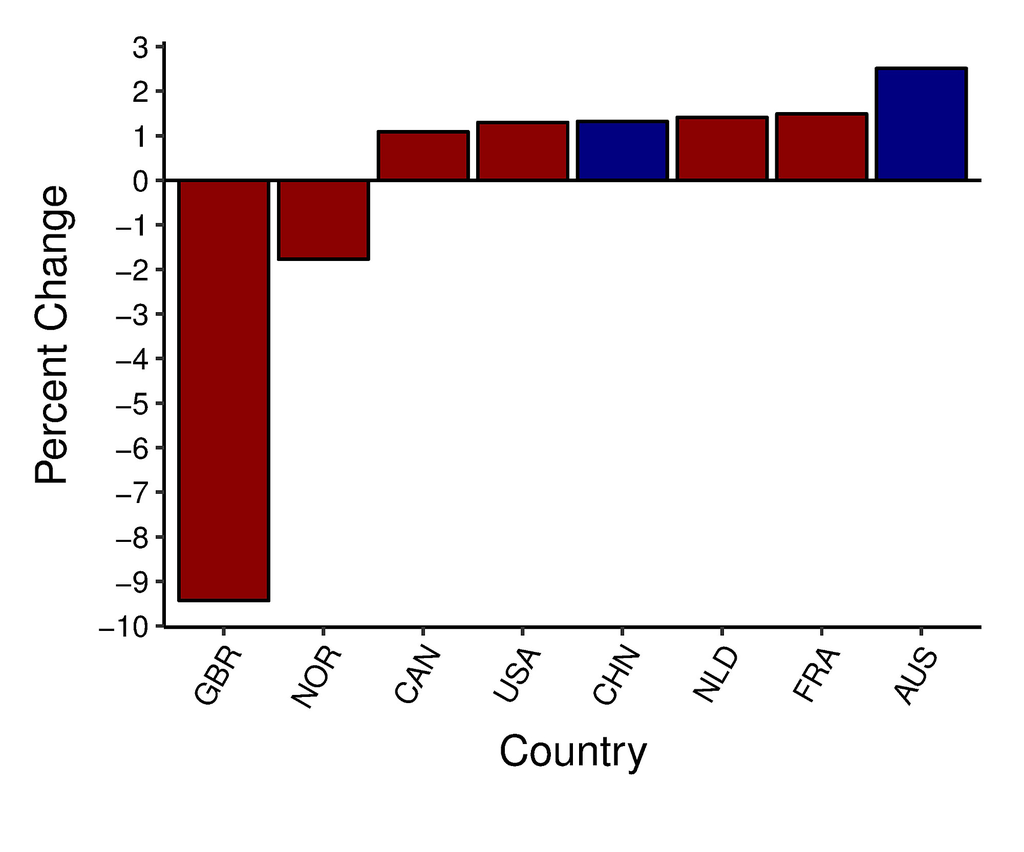

Percent change in the proportion of total editors from different countries from 1985 to 2014.

(TIF)

### [S1 Fig.](https://journals.plos.org/plosbiology/article/file?type=supplementary&id=10.1371/journal.pbio.2002760.s001) Percent change in the proportion of total editors from different countries from 1985 to 2014.

https://doi.org/10.1371/journal.pbio.2002760.s001

(TIF)

### [S2 Fig.](https://journals.plos.org/plosbiology/article/file?type=supplementary&id=10.1371/journal.pbio.2002760.s002) Proportion of the 1<sup>st</sup> authors of papers published in N = 24 environmental biology journals in 2014 that were based in different countries.

https://doi.org/10.1371/journal.pbio.2002760.s002

(TIF)

### [S3 Fig.](https://journals.plos.org/plosbiology/article/file?type=supplementary&id=10.1371/journal.pbio.2002760.s003) Geographic richness of editorial boards in environmental biology (1985–2014).

The Geographic Richness (i.e., number of countries represented) of N = 24 environmental biology editorial boards from 1985–2014.

https://doi.org/10.1371/journal.pbio.2002760.s003

(TIF)

### [S4 Fig.](https://journals.plos.org/plosbiology/article/file?type=supplementary&id=10.1371/journal.pbio.2002760.s004) Geographic diversity of editorial boards in environmental biology (1985–2014).

Geographic Diversity, calculated as the inverse of Simpson’s Index, D2, of N = 24 environmental biology editorial boards from 1985–2014.

https://doi.org/10.1371/journal.pbio.2002760.s004

(TIF)

### [S5 Fig.](https://journals.plos.org/plosbiology/article/file?type=supplementary&id=10.1371/journal.pbio.2002760.s005) Representation of different global regions on editorial boards in environmental biology (1985–2014).

The percentage of editors for each of N = 24 environmental biology journals that are based different global regions (1985–2014).

https://doi.org/10.1371/journal.pbio.2002760.s005

(TIF)

### [S6 Fig.](https://journals.plos.org/plosbiology/article/file?type=supplementary&id=10.1371/journal.pbio.2002760.s006) Representation of national income categories on N = 24 editorial boards (1985–2014).

The percentage of editors for each of N = 24 environmental biology journals that are based in countries belonging to different World Bank National Income categories (1985–2014).

https://doi.org/10.1371/journal.pbio.2002760.s006

(TIF)

### [S1 Table.](https://journals.plos.org/plosbiology/article/file?type=supplementary&id=10.1371/journal.pbio.2002760.s007) Focal environmental biology journals.

We used N = 24 environmental biology journals in our survey of international representation on editorial boards between 1985–2014.

https://doi.org/10.1371/journal.pbio.2002760.s007

(DOCX)

### [S2 Table.](https://journals.plos.org/plosbiology/article/file?type=supplementary&id=10.1371/journal.pbio.2002760.s008) 2014 editors and authors.

The proportion of editors for and first-authors of articles in N = 24 environmental biology journals that are based in different (A) Global Regions and (B) National Income Categories.

https://doi.org/10.1371/journal.pbio.2002760.s008

(DOCX)

### [S1 Text.](https://journals.plos.org/plosbiology/article/file?type=supplementary&id=10.1371/journal.pbio.2002760.s009) Data collection methods, analyses, and results.

The study as based on the 1985–2014 Editorial Boards of N = 24 environmental biology journals.

https://doi.org/10.1371/journal.pbio.2002760.s009

(DOCX)

## Acknowledgments

We thank Juan Pablo Gomez for helpful discussions and assistance with data collection. This manuscript was completed while EB was Faculty-in-Residence at the University of Florida Marston Science Library. Additional logistical support was also provided by the University of Florida Bureau of Economic and Business Research and the University of Florida Informatics Institute.

## References

1. 1. Ware M, Mabe M. The STM report: An overview of scientific and scholarly journal publishing. 2015 [cited 2017 Apr 15]. International Association of Scientific Technical and Medical Publishers.The Hague, The Netherlands. http://www.stm-assoc.org/2015_02_20_STM_Report_2015.pdf
2. 2. Crane D. The gatekeepers of science: Some factors affecting the selection of articles for scientific journals. The American Sociologist. 1967;2(4):195–201.
   - View Article
   - [Google Scholar](http://scholar.google.com/scholar?q=The+gatekeepers+of+science%3A+Some+factors+affecting+the+selection+of+articles+for+scientific+journals+Crane+1967)
3. 3. Metz I, Harzing A-W. Gender diversity in editorial boards of management journals. Academy of Management Learning & Education. 2009;8(4):540–57.
   - [View Article](https://doi.org/10.5465/AMLE.2009.47785472)
   - [Google Scholar](http://scholar.google.com/scholar?q=Gender+diversity+in+editorial+boards+of+management+journals+Metz+2009)
4. 4. Garcia-Carpintero E, Granadino B, Plaza LM. The representation of nationalities on the editorial boards of international journals and the promotion of the scientific output of the same countries. Scientometrics. 2010;84(3):799–811.
   - [View Article](https://doi.org/10.1007/s11192-010-0199-3)
   - Google Scholar
5. 5. Cho AH, Johnson SA, Schuman CE, Adler JM, Gonzalez O, Graves SJ, et al. Women are underrepresented on the editorial boards of journals in environmental biology and natural resource management. PeerJ. 2014;2:e542. pmid:25177537
   - [View Article](https://doi.org/10.7717/peerj.542)
   - [PubMed/NCBI](http://www.ncbi.nlm.nih.gov/pubmed/25177537)
   - [Google Scholar](http://scholar.google.com/scholar?q=Women+are+underrepresented+on+the+editorial+boards+of+journals+in+environmental+biology+and+natural+resource+management+Cho+2014)
6. 6. Cox TH, Blake S. Managing cultural diversity: Implications for organizational competitiveness. The Executive. 1991:45–56.
   - View Article
   - [Google Scholar](http://scholar.google.com/scholar?q=Managing+cultural+diversity%3A+Implications+for+organizational+competitiveness+Cox+1991)
7. 7. Mazov NA, Gureev VN. The editorial boards of scientific journals as a subject of scientometric research: a literature review. Scientific and Technical Information Processing. 2016;43(3):144–53.
   - [View Article](https://doi.org/10.3103/s0147688216030035)
   - [Google Scholar](http://scholar.google.com/scholar?q=The+editorial+boards+of+scientific+journals+as+a+subject+of+scientometric+research%3A+a+literature+review+Mazov+2016)
8. 8. Fox CW, Burns CS, Meyer JA, Thompson K. Editor and reviewer gender influence the peer review process but not peer review outcomes at an ecology journal. Functional Ecology. 2016;30(1):140–53.
   - [View Article](https://doi.org/10.1111/1365-2435.12529)
   - [Google Scholar](http://scholar.google.com/scholar?q=Editor+and+reviewer+gender+influence+the+peer+review+process+but+not+peer+review+outcomes+at+an+ecology+journal+Fox+2016)
9. 9. Holmgren M, Schnitzer SA. Science on the rise in developing countries. PLoS Biol. 2004;2(1):e1. pmid:14737181
   - [View Article](https://doi.org/10.1371/journal.pbio.0020001)
   - [PubMed/NCBI](http://www.ncbi.nlm.nih.gov/pubmed/14737181)
   - [Google Scholar](http://scholar.google.com/scholar?q=Science+on+the+rise+in+developing+countries+Holmgren+2004)
10. 10. Smith MJ, Weinberger C, Bruna EM, Allesina S. The scientific impact of nations: Journal placement and citation performance. PLoS ONE. 2014;9(10):e109195. pmid:25296039
    - [View Article](https://doi.org/10.1371/journal.pone.0109195)
    - [PubMed/NCBI](http://www.ncbi.nlm.nih.gov/pubmed/25296039)
    - [Google Scholar](http://scholar.google.com/scholar?q=The+scientific+impact+of+nations%3A+Journal+placement+and+citation+performance+Smith+2014)
11. 11. Mammides C, Goodale UM, Corlett RT, Chen J, Bawa KS, Hariya H, et al. Increasing geographic diversity in the international conservation literature: A stalled process? Biological Conservation. 2016;198:78–83.
    - [View Article](https://doi.org/10.1016/j.biocon.2016.03.030)
    - [Google Scholar](http://scholar.google.com/scholar?q=Increasing+geographic+diversity+in+the+international+conservation+literature%3A+A+stalled+process%3F+Mammides+2016)
12. 12. Meneghini R, Packer AL, Nassi-Calo L. Articles by Latin American authors in prestigious journals have fewer citations. PLoS ONE. 2008;3(11). pmid:19030227
    - [View Article](https://doi.org/10.1371/journal.pone.0003804)
    - [PubMed/NCBI](http://www.ncbi.nlm.nih.gov/pubmed/19030227)
    - [Google Scholar](http://scholar.google.com/scholar?q=Articles+by+Latin+American+authors+in+prestigious+journals+have+fewer+citations+Meneghini+2008)
13. 13. Bakker P, Rigter H. Editors of medical journals—who and from where. Scientometrics. 1985;7(1–2):11–22.
    - [View Article](https://doi.org/10.1007/bf02020137)
    - [Google Scholar](http://scholar.google.com/scholar?q=Editors+of+medical+journals%E2%80%94who+and+from+where+Bakker+1985)
14. 14. Braun T, Bujdoso E. Gatekeeping patterns in the publication of analytical-chemistry research. Talanta. 1983;30(3):161–7. pmid:18963339
    - View Article
    - [PubMed/NCBI](http://www.ncbi.nlm.nih.gov/pubmed/18963339)
    - [Google Scholar](http://scholar.google.com/scholar?q=Gatekeeping+patterns+in+the+publication+of+analytical-chemistry+research+Braun+1983)
15. 15. Nisonger TE. The relationship between international editorial board composition and citation measures in political science, business, and genetics journals. Scientometrics. 2002;54(2):257–68.
    - [View Article](https://doi.org/10.1023/A:1016065929026)
    - [Google Scholar](http://scholar.google.com/scholar?q=The+relationship+between+international+editorial+board+composition+and+citation+measures+in+political+science%2C+business%2C+and+genetics+journals+Nisonger+2002)
16. 16. Livingston G, Waring B, Pacheco LF, Buchori D, Jiang YX, Gilbert L, et al. Perspectives on the global disparity in ecological science. Bioscience. 2016;66(2):147–55.
    - [View Article](https://doi.org/10.1093/biosci/biv175)
    - [Google Scholar](http://scholar.google.com/scholar?q=Perspectives+on+the+global+disparity+in+ecological+science+Livingston+2016)
17. 17. Cho AH, Johnson SA, Schuman CE, Adler JM, Gonzalez O, Graves SJ, et al. Data from "Women are underrepresented on the editorial boards of journals in environmental biology and natural resource management (PeerJ)". 2014; Database: Dryad Digital Repository. http://doi.org/10.5061/dryad.6jn86.
    - View Article
    - [Google Scholar](http://scholar.google.com/scholar?q=Data+from+%26quot%3BWomen+are+underrepresented+on+the+editorial+boards+of+journals+in+environmental+biology+and+natural+resource+management+%28PeerJ%29%26quot%3B+Cho+2014)
18. 18. Espin J, Palmas S, Carrasco-Rueda F, Riemer K, Allen PE, Berkebile N, et al. Data from "A persistent lack of international representation on editorial boards in environmental biology (PLoS Biol.)". 2017; Database: Dryad Digital Repository. https://doi.org/10.5061/dryad.mh189.
    - View Article
    - [Google Scholar](http://scholar.google.com/scholar?q=Data+from+%26quot%3BA+persistent+lack+of+international+representation+on+editorial+boards+in+environmental+biology+%28PLoS+Biol.%29%26quot%3B+Espin+2017)
19. 19. Independent Commission on International Development Issues. North-South: a programme for survival: report of the Independent Commission on International Development Issues. Cabridge, MA: MIT Press; 1980.
20. 20. Habel JC, Lens L, Eggermont H, Githiru M, Mulwa RK, Shauri HS, et al. More topics from the tropics: additional thoughts to Mammides et al. Biodiversity and Conservation. 2017;26(1):237–41.
    - [View Article](https://doi.org/10.1007/s10531-016-1236-1)
    - [Google Scholar](http://scholar.google.com/scholar?q=More+topics+from+the+tropics%3A+additional+thoughts+to+Mammides+et+al+Habel+2017)
21. 21. UNESCO. Number of Researchers per million inhabitants by country, United Nations Educational, Scientific and Cultural Organisation (UNESCO) Institute for Statistics. 2011.
22. 22. Stocks G, Seales L, Paniagua F, Maehr E, Bruna EM. The geographical and institutional distribution of ecological research in the tropics. Biotropica. 2008;40(4):397–404.
    - [View Article](https://doi.org/10.1111/j.1744-7429.2007.00393.x)
    - [Google Scholar](http://scholar.google.com/scholar?q=The+geographical+and+institutional+distribution+of+ecological+research+in+the+tropics+Stocks+2008)
23. 23. Campos-Arceiz A, Primack RB, Koh LP. Reviewer recommendations and editors’ decisions for a conservation journal: Is it just a crapshoot? And do Chinese authors get a fair shot? Biological Conservation. 2015;186:22–7.
    - [View Article](https://doi.org/10.1016/j.biocon.2015.02.025)
    - Google Scholar
24. 24. Primack RB, Ellwood E, Miller-Rushing AJ, Marrs R, Mulligan A. Do gender, nationality, or academic age affect review decisions? An analysis of submissions to the journal Biological Conservation. Biological Conservation. 2009;142(11):2415–8.
    - [View Article](https://doi.org/10.1016/j.biocon.2009.06.021)
    - [Google Scholar](http://scholar.google.com/scholar?q=Do+gender%2C+nationality%2C+or+academic+age+affect+review+decisions%3F+An+analysis+of+submissions+to+the+journal+Biological+Conservation+Primack+2009)
25. 25. Lee CJ, Sugimoto CR, Zhang G, Cronin B. Bias in peer review. Journal of the American Society for Information Science and Technology. 2013;64(1):2–17.
    - [View Article](https://doi.org/10.1002/asi.22784)
    - [Google Scholar](http://scholar.google.com/scholar?q=Bias+in+peer+review+Lee+2013)
26. 26. Mori AS, Qian SH, Tatsumi S. Academic inequality through the lens of community ecology: a meta-analysis. PeerJ. 2015;3(3):e1457. pmid:26644987
    - [View Article](https://doi.org/10.7717/peerj.1457)
    - [PubMed/NCBI](http://www.ncbi.nlm.nih.gov/pubmed/26644987)
    - [Google Scholar](http://scholar.google.com/scholar?q=Academic+inequality+through+the+lens+of+community+ecology%3A+a+meta-analysis+Mori+2015)
27. 27. Meijaard E, Cardillo M, Meijaard EM, Possingham HP. Geographic bias in citation rates of conservation research. Conserv Biol. 2015;29(3):920–5. pmid:25817796
    - [View Article](https://doi.org/10.1111/cobi.12489)
    - [PubMed/NCBI](http://www.ncbi.nlm.nih.gov/pubmed/25817796)
    - [Google Scholar](http://scholar.google.com/scholar?q=Geographic+bias+in+citation+rates+of+conservation+research+Meijaard+2015)
28. 28. Menges RJ, Exum WH. Barriers to the progress of women and minority faculty. The Journal of Higher Education. 1983;54(2):123–44.
    - [View Article](https://doi.org/10.1080/00221546.1983.11778167)
    - [Google Scholar](http://scholar.google.com/scholar?q=Barriers+to+the+progress+of+women+and+minority+faculty+Menges+1983)
29. 29. Pearson C, Mullen R, Thomason W, Phillips S. Associate editor’s role in helping authors and upholding journal standards. Agronomy Journal. 2006;98(3):417–22.
    - [View Article](https://doi.org/10.2134/agronj2005.0296)
    - [Google Scholar](http://scholar.google.com/scholar?q=Associate+editor%E2%80%99s+role+in+helping+authors+and+upholding+journal+standards+Pearson+2006)
30. 30. Liao C. How to improve research quality? Examining the impacts of collaboration intensity and member diversity in collaboration networks. Scientometrics. 2011;86(3):747–61.
    - [View Article](https://doi.org/10.1007/s11192-010-0309-2)
    - [Google Scholar](http://scholar.google.com/scholar?q=How+to+improve+research+quality%3F+Examining+the+impacts+of+collaboration+intensity+and+member+diversity+in+collaboration+networks+Liao+2011)
31. 31. Campos-Arceiz A, Primack RB, Miller-Rushing AJ, Maron M. Striking underrepresentation of biodiversity-rich regions among editors of conservation journals. Biological Conservation. 2017.
    - [View Article](https://doi.org/10.1016/j.biocon.2017.07.028)
    - [Google Scholar](http://scholar.google.com/scholar?q=Striking+underrepresentation+of+biodiversity-rich+regions+among+editors+of+conservation+journals+Campos-Arceiz+2017)
32. 32. Karlsson S. The North-South knowledge divide: consequences for global environmental governance. Strengthening Global Environmental Governance: Options and Opportunities: Yale School of Forestry & Environmental Studies; 2002. p. 1–24.
33. 33. Calver M, Wardell-Johnson G, Bradley S, Taplin R. What makes a journal international? A case study using conservation biology journals. Scientometrics. 2010;85(2):387–400.
    - [View Article](https://doi.org/10.1007/s11192-010-0273-x)
    - [Google Scholar](http://scholar.google.com/scholar?q=What+makes+a+journal+international%3F+A+case+study+using+conservation+biology+journals+Calver+2010)

[Download PDF](https://journals.plos.org/plosbiology/article/file?id=10.1371/journal.pbio.2002760&type=printable)

- [Citation](https://journals.plos.org/plosbiology/article/citation?id=10.1371/journal.pbio.2002760)
- [XML](https://journals.plos.org/plosbiology/article/file?id=10.1371/journal.pbio.2002760&type=manuscript)

Print

- Print article
- [Reprints](http://surveys.plos.org/s3/reprints)

Share

[figure not shown]

### Included in the Following Collection

- [Meta-Research: Policy and Interventions](https://collections.plos.org/collection/meta-research-policy-and-interventions/)

Advertisement

  Is the Subject Area **"Biogeography"** applicable to this article?

  Is the Subject Area **"Scientists"** applicable to this article?

  Is the Subject Area **"Environmental geography"** applicable to this article?

  Is the Subject Area **"Scientific publishing"** applicable to this article?

  Is the Subject Area **"Asia"** applicable to this article?

  Thanks for your feedback.
- [Community ecology](https://journals.plos.org/plosbiology/search?filterSubjects=Community+ecology&filterJournals=PLoSBiology&q=)

  Is the Subject Area **"Community ecology"** applicable to this article?

  Thanks for your feedback.
- [Geography](https://journals.plos.org/plosbiology/search?filterSubjects=Geography&filterJournals=PLoSBiology&q=)

  Is the Subject Area **"Geography"** applicable to this article?

  Thanks for your feedback.
- [Medical journals](https://journals.plos.org/plosbiology/search?filterSubjects=Medical+journals&filterJournals=PLoSBiology&q=)

  Is the Subject Area **"Medical journals"** applicable to this article?

  Thanks for your feedback.